# Bureau of Transportation

Tyler Yankee

2022-09-13

## Load packages

```r
library(tidyverse)
library(here)
library(janitor)
```

## Load the BOT data

```r
df2019 = read_csv(here("data_raw", "BOT.zip")) %>% clean_names()
```

## Subsetting to data of interest

Let’s focus on flights from La Guardia (airport “LGA”) and eliminate cargo flights by requiring at leat 1 passenger.

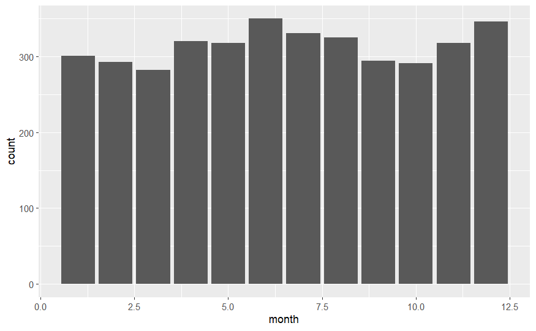

```r
df9 = df2019 %>% filter(passengers > 0, origin == "LGA")
df9 %>% ggplot(aes(month)) + geom_bar()
```

By default, geom_bar is counting the number of rows, where we asked it to visualize the count by month.

Counting rows is not going to give us a count of flights because in this dataset, the number of departures is different per row.

The visualization we want is:

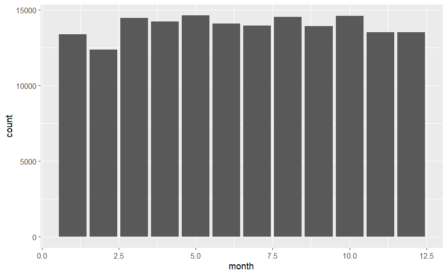

```r
df9 %>% ggplot(aes(month)) + geom_bar(aes(weight = departures_performed))
```

## A new visualization

Can you make a bar chart where the bar height is based on the number of passengers riding each month?

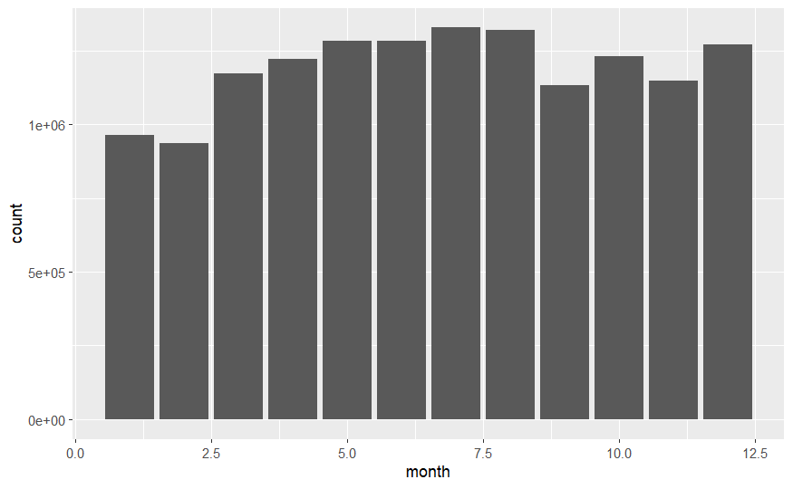

```r
df9 %>% ggplot(aes(x = month)) + geom_bar(aes(weight = passengers))
```

## Just because you can

Here is a pretty, but not so useful plot.

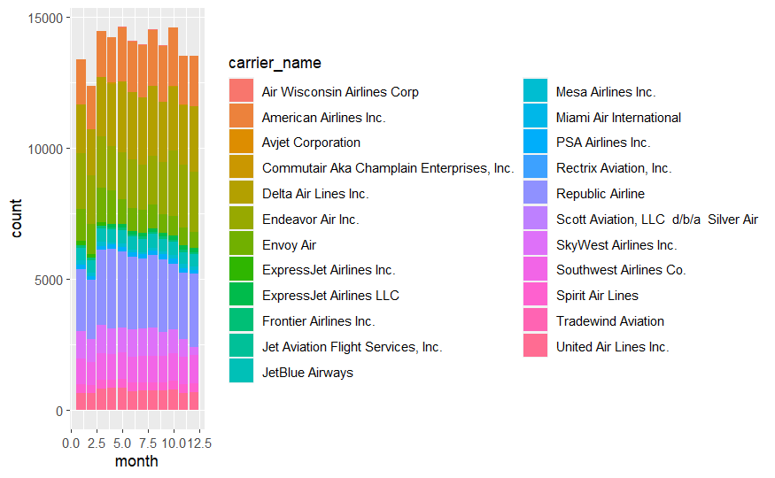

```r
df9 %>% ggplot(aes(month, fill = carrier_name)) +
  geom_bar(aes(weight = departures_performed))
```

## New perspective

Let’s filter our dataset based on people leaving *and* entering La Guardia.

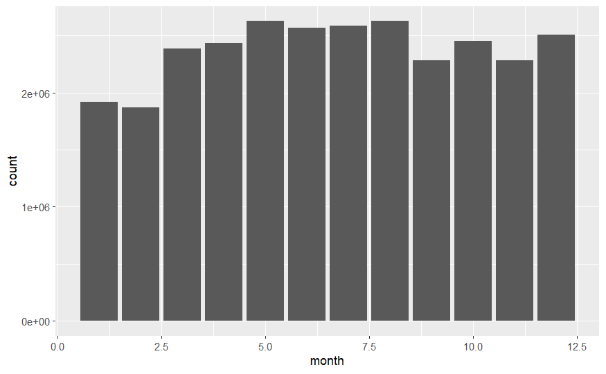

```r
df10 = df2019 %>% filter(passengers > 0, origin == "LGA" | dest == "LGA")
df10 %>% ggplot(aes(x = month)) + geom_bar(aes(weight = passengers))
```

## Add a new variable, percent_loading

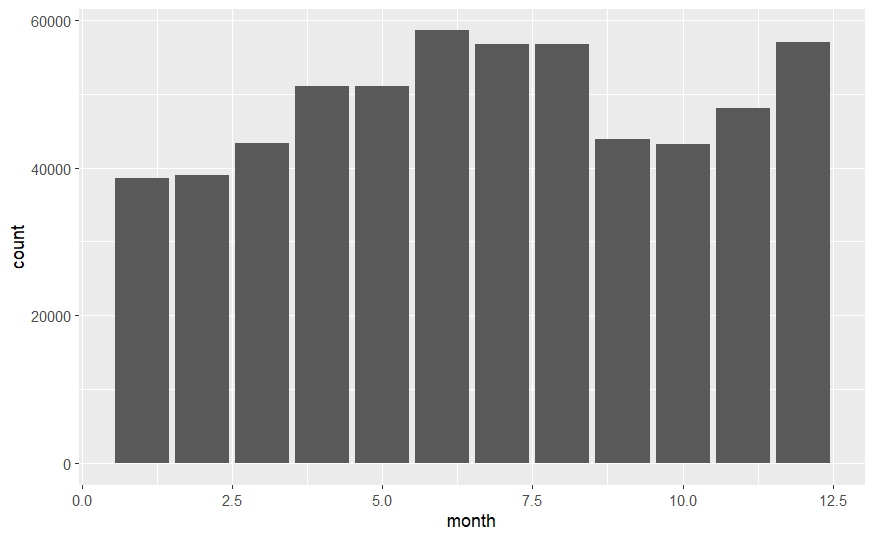

```r
df11 = df10 %>% select(month, passengers, seats, carrier_name, origin, dest)
df13 = df11 %>% mutate(percent_loading = passengers / seats * 100)
df13 %>% ggplot(aes(x = month)) + geom_bar(aes(weight = percent_loading))
```

## Analyze percent_loading with 4 different airlines

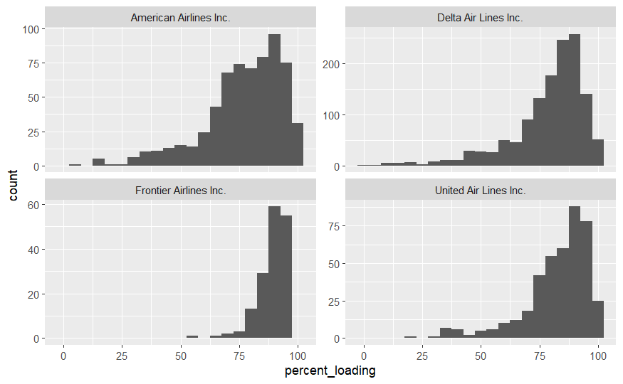

```r
carriers <- c("American Airlines Inc.", "Delta Air Lines Inc.", "Frontier Airlines Inc.", "United Air Lines Inc.")
df14 = df13 %>% filter(
  carrier_name %in% carriers
)
df14 %>% ggplot(aes(x = percent_loading)) + geom_histogram(binwidth = 5) + facet_wrap(~carrier_name, scales = "free_y")
```

## Summarize data

```r
df15 = df2019 %>% filter(passengers > 0, origin == "LGA" | dest == "LGA") %>%
  group_by(month) %>% summarise(total_pass = sum(passengers))

# Side track - note the inheritance and the difference between the two data types here
df15a = df2019 %>% filter(passengers > 0, origin == "LGA" | dest == "LGA") %>%
  group_by(month)
df15b = df2019 %>% filter(passengers > 0, origin == "LGA" | dest == "LGA")
class(df15)
```

```
[1] "tbl_df"     "tbl"        "data.frame"
```

```r
class(df15a)
```

```
[1] "grouped_df" "tbl_df"     "tbl"        "data.frame"
```

```r
class(df15b)
```

```
[1] "spec_tbl_df" "tbl_df"      "tbl"         "data.frame"
```

```r
class(df2019)
```

```
[1] "spec_tbl_df" "tbl_df"      "tbl"         "data.frame"
```

```r
# Anyway, let's continue summarizing
# Get the total passengers for each month, the total number of flights each month, and the average number of passengers per flight
# Also group by carrier
df16 = df2019 %>% filter(passengers > 0, origin == "LGA" | dest == "LGA") %>%
  group_by(month, carrier_name) %>%
  summarise(total_pass = sum(passengers), num_flights = sum(departures_performed)) %>%
  mutate(average_pass_per_flight = total_pass / num_flights)
```

[output not shown]

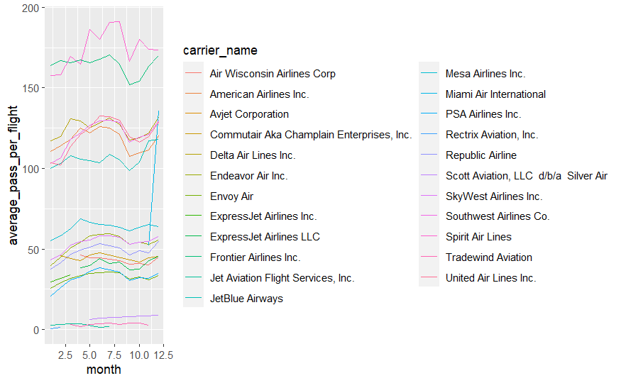

```r
df16 %>% ggplot(aes(x = month, y = average_pass_per_flight, color = carrier_name)) + geom_line()
```

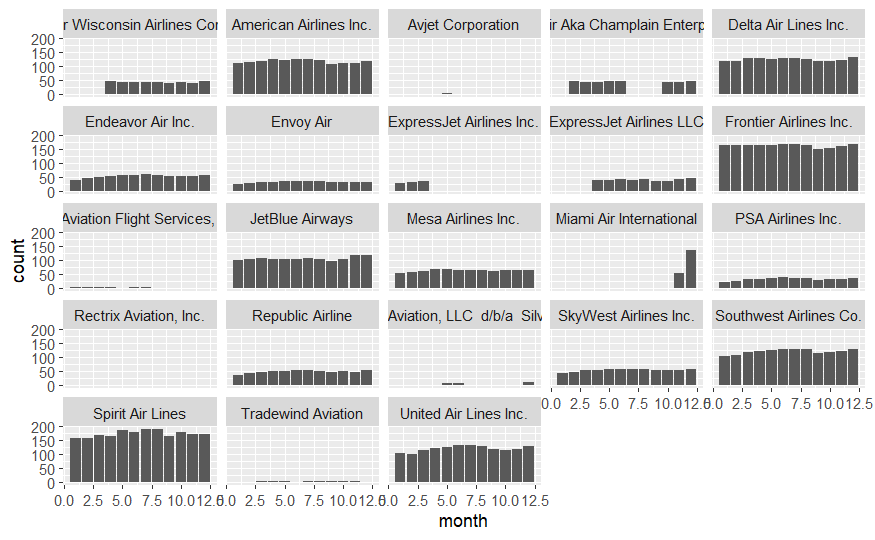

```r
df16 %>% ggplot(aes(x = month)) + geom_bar(aes(weight = average_pass_per_flight)) +
  facet_wrap(~carrier_name)
```

Some thoughts on the above graph: - there are 4 main clumps of data - could be due to different sizes of planes - generally the pattern over the course of the year is the same across each airline - Jan low, July/Aug high - incomplete data for some airlines - so many airlines on one graph that it’s difficult to differentiate the colors

Let’s look at the number of seats instead of passengers -

```r
df16a = df2019 %>% filter(passengers > 0, origin == "LGA" | dest == "LGA") %>%
  group_by(month, carrier_name) %>%
  summarise(total_seats = sum(seats), num_flights = sum(departures_performed)) %>%
  mutate(average_seats_per_flight = total_seats / num_flights)
```

[output not shown]

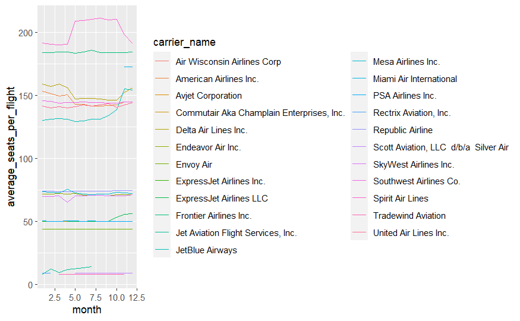

```r
df16a %>% ggplot(aes(x = month, y = average_seats_per_flight, color = carrier_name)) + geom_line()
```

This raises an interesting question: is spirit Air Lines reconfiguring their seats in the summer months, or are they using different planes?

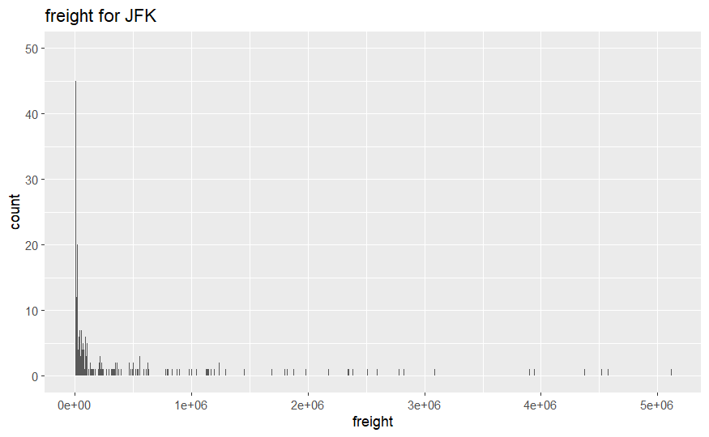

```r
# These two dataframes represent flights only carrying cargo (mail or freight) to and from the two major NYC airports.
df17 = df2019 %>% filter(freight > 0 | mail > 0, origin == "JFK" | dest == "JFK")
df18 = df2019 %>% filter(freight > 0 | mail > 0, origin == "LGA" | dest == "LGA")

df17 %>% ggplot(aes(x = freight)) + geom_histogram(binwidth = 1000) +
  ggtitle("freight for JFK") + ylim(0, 50)
```

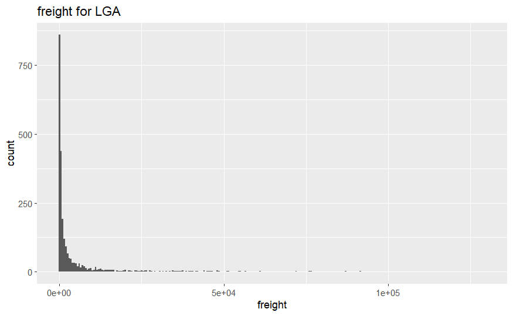

```r
df18 %>% ggplot(aes(x = freight)) + geom_histogram(binwidth = 500) +
  ggtitle("freight for LGA")
```